# Market Basket analysis of Cosmetics

[Home](https://annepu-ram.github.io/)

## Ram Annepu

### Association Rule mining

[figure not shown]

# Market Basket analysis of Cosmetics

seetharam annepu 71710036

8 September 2017

```r
ifelse(require(arules),{library("arules")},install.packages("arules"))
```

```
## [1] "arules"
```

```r
ifelse(require(readxl),{library("readxl")},install.packages("readxl"))
```

```
## [1] "readxl"
```

```r
ifelse(require(Matrix),{library("Matrix")},install.packages("Matrix"))
```

```
## [1] "readxl"
```

```r
ifelse(require(arulesViz),{library("arulesViz")},install.packages("arulesViz"))
```

```
## [1] "arulesViz"
```

```r
mydata<-read_excel(file.choose(),sheet =2,col_names = T)
mydata<-mydata[-2]
mydata<-mydata[-1]
cosmetics<-as.matrix(mydata)
nrow(cosmetics)
```

```
## [1] 1000
```

we need to convert the data frame into transactions type data. transaction matrix is a sparce matrix and acccepts only trasaction type data which is of the form citrus fruit, semi-finished bread, margarine, ready soups tropical fruit, yogurt, coffee  
whole milk  
pip fruit, yogurt, cream cheese, meat spreads

but what we have is a logical matrix Bag Blush Nail Polish Brushes Concealer Eyebrow Pencils Bronzer Lip liner Mascara Eye shadow Foundation Lip Gloss Lipstick Eyeliner 0 1 1 1 1 0 1 1 1 0 0 0 0 1 0 0 1 0 1 0 1 1 0 0 1 1 0 0 0 1 0 0 1 1 1 1 1 1 1 1 1 0

hence we need to convert logical matrix into transaction type matrix

```r
cosmetics <-apply(cosmetics,2,as.logical)
cosmetics <- as(cosmetics, "transactions")
```

most purchased items

```r
itemFrequency(cosmetics)
```

```
##             Bag           Blush     Nail Polish         Brushes
##           0.054           0.363           0.280           0.149
##       Concealer Eyebrow Pencils         Bronzer       Lip liner
##           0.442           0.042           0.279           0.234
##         Mascara      Eye shadow      Foundation       Lip Gloss
##           0.357           0.381           0.536           0.490
##        Lipstick        Eyeliner
##           0.322           0.457
```

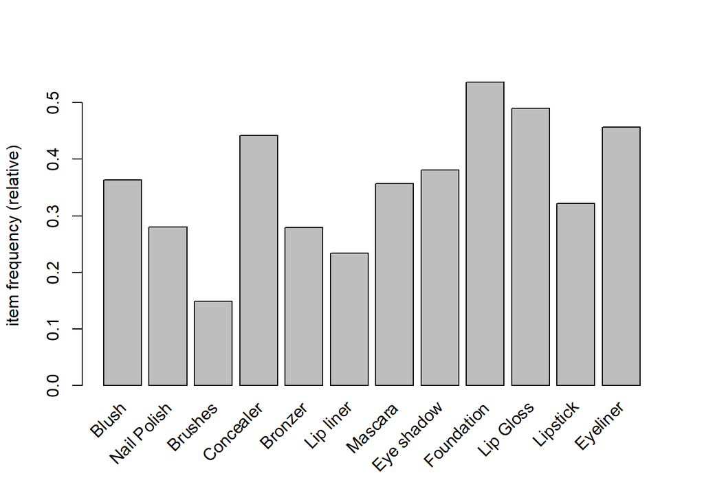

```r
itemFrequencyPlot(cosmetics, support = 0.1)
```

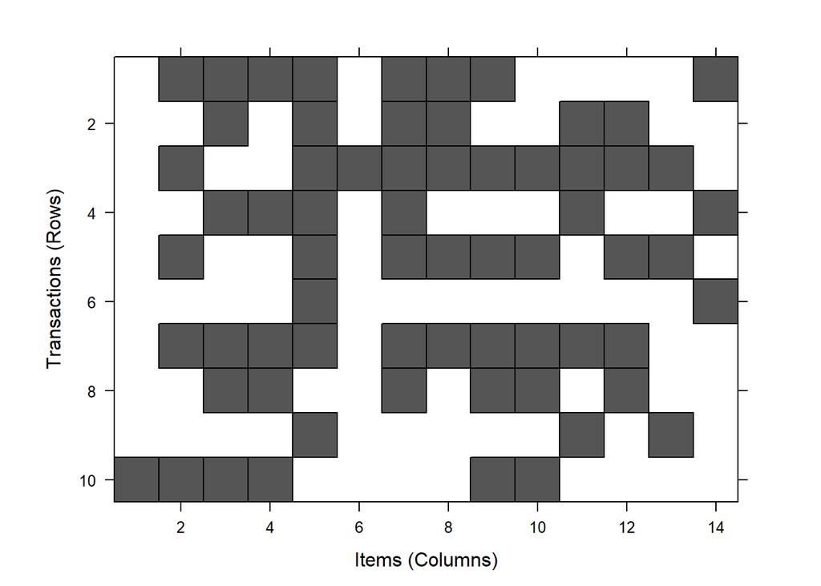

```r
image(cosmetics[1:10])
```

## Now the building blocks of the association rule mining are

Support: percentage of transactions in antecedent and consequent co-occur Confidence: this is a conditional probability. given the probability of occurance of antecedent what is the probability of occurence of consequent and Lift:actual confidence divided by confidence of the pair assuming they are independent. in other words, lift is used to determine that the association is not random and the consequent is really dependent on the antecedent

enough of theory time to dig these rules out of the data

```r
rules = apriori(cosmetics, parameter=list(support=0.1, confidence=0.8,minlen=1,maxlen=5))
```

```
## Apriori
##
## Parameter specification:
##  confidence minval smax arem  aval originalSupport maxtime support minlen
##         0.8    0.1    1 none FALSE            TRUE       5     0.1      1
##  maxlen target   ext
##       5  rules FALSE
##
## Algorithmic control:
##  filter tree heap memopt load sort verbose
##     0.1 TRUE TRUE  FALSE TRUE    2    TRUE
##
## Absolute minimum support count: 100
##
## set item appearances ...[0 item(s)] done [0.00s].
## set transactions ...[14 item(s), 1000 transaction(s)] done [0.00s].
## sorting and recoding items ... [12 item(s)] done [0.00s].
## creating transaction tree ... done [0.00s].
## checking subsets of size 1 2 3 4 done [0.00s].
## writing ... [26 rule(s)] done [0.00s].
## creating S4 object  ... done [0.00s].
```

```r
rules
```

```
## set of 26 rules
```

```r
inspect(head(sort(rules, by="lift"),15))
```

```
##      lhs                                rhs           support confidence
## [1]  {Brushes}                       => {Nail Polish} 0.149   1.0000000
## [2]  {Blush,Concealer,Eye shadow}    => {Mascara}     0.119   0.9596774
## [3]  {Blush,Eye shadow}              => {Mascara}     0.169   0.9285714
## [4]  {Nail Polish,Eye shadow}        => {Mascara}     0.119   0.9083969
## [5]  {Concealer,Eye shadow}          => {Mascara}     0.179   0.8905473
## [6]  {Bronzer,Eye shadow}            => {Mascara}     0.124   0.8794326
## [7]  {Concealer,Eye shadow,Eyeliner} => {Mascara}     0.114   0.8769231
## [8]  {Blush,Mascara}                 => {Eye shadow}  0.169   0.9184783
## [9]  {Eye shadow,Lipstick}           => {Mascara}     0.110   0.8527132
## [10] {Mascara,Lipstick}              => {Eye shadow}  0.110   0.9090909
## [11] {Blush,Concealer,Mascara}       => {Eye shadow}  0.119   0.9083969
## [12] {Bronzer,Mascara}               => {Eye shadow}  0.124   0.9051095
## [13] {Mascara}                       => {Eye shadow}  0.321   0.8991597
## [14] {Eye shadow}                    => {Mascara}     0.321   0.8425197
```

[output cut: 17 more lines]

```r
rules.sorted<-head(sort(rules, by="lift"),15)
inspect(head(sort(rules, by="lift"),1))
```

```
##     lhs          rhs           support confidence lift     count
## [1] {Brushes} => {Nail Polish} 0.149   1          3.571429 149
```

```r
df.nail.brush<-data.frame(`nail polish`=mydata[,3],`Brushes`=mydata[,4])
table(df.nail.brush)
```

```
##            Brushes
## Nail.Polish   0   1
##           0 720   0
##           1 131 149
```

hence Support for first rule: {Brushes} => {Nail Polish} is ((total people who bought both Brushes and nail polish together)/(total transactions)) = 149/1000 = 0.149 similarly Confidence(Brushes, Nail Polish) = P(Nail Polish/Brushes) = P(Brushes & Nail.Polish) / P(Brushes) = 0.149 / 0.149 = 1 = 100 % all the people who bought brushes bought nail polish. Lift Ratio = 1(from above)/0.28 = 3.5714 it is 3.5 times likely that brushes are bought with nail polish.

```
## To reduce overplotting, jitter is added! Use jitter = 0 to prevent jitter.
```

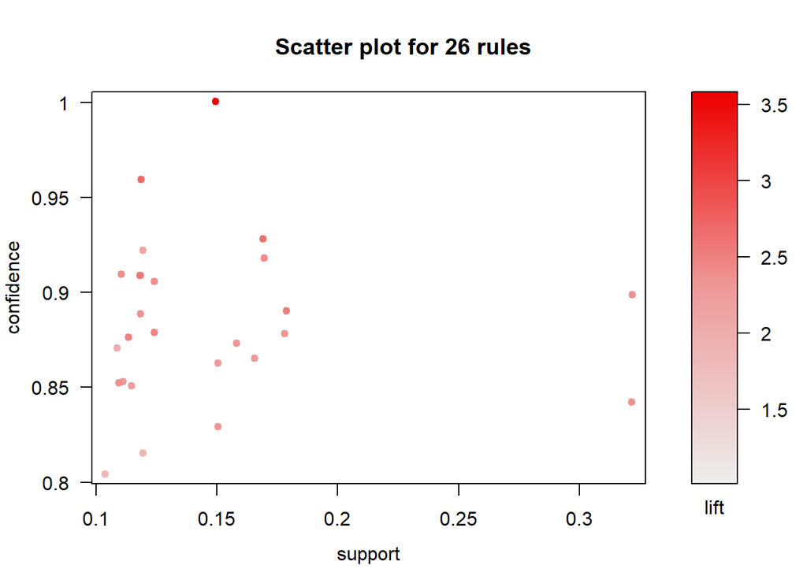

```r
plot(rules)
```

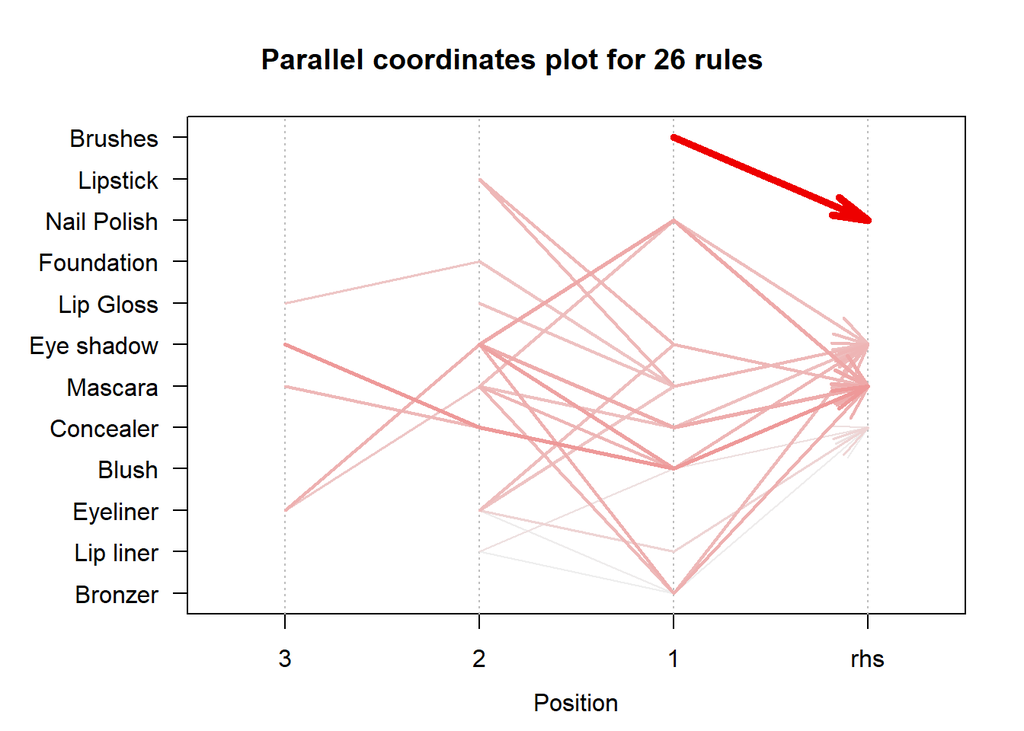

```r
#plot(rules, method="matrix", measure="lift", control=list(reorder="support"))

plot(rules, method="paracoord",measure="lift", control=list(reorder=TRUE))
```

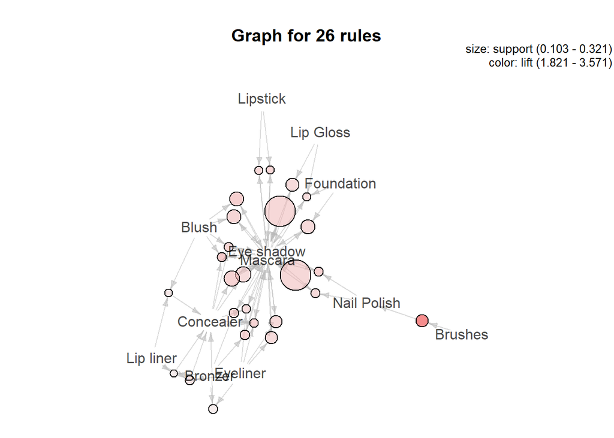

```r
plot(rules, method="graph")
```

[output not shown]

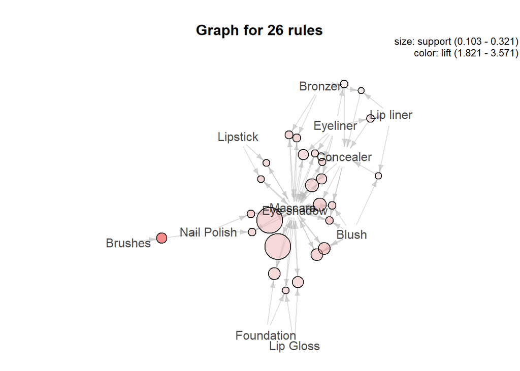

```r
## igraph layout generators can be used (see ? igraph::layout_)
#plot(rules, method="graph", control=list(layout=igraph::in_circle()))
plot(rules, method="graph", control=list(type="itemsets"))
```

Redundant rules can be found out by putting the antecedant and consequent in the same basket and building a matrix based on these rules. the matrix represents all rules created from same item set. the redundant rules are

```r
subset.matrix <- is.subset(rules.sorted, rules.sorted)
subset.matrix<-subset.matrix*1
subset.matrix[lower.tri(subset.matrix, diag=T)] <- NA
redundant <- colSums(subset.matrix, na.rm=T) >= 1
which(redundant)
```

```
## {Concealer,Mascara,Eye shadow,Eyeliner}
##                                       7
##              {Blush,Mascara,Eye shadow}
##                                       8
##           {Mascara,Eye shadow,Lipstick}
##                                      10
##    {Blush,Concealer,Mascara,Eye shadow}
##                                      11
##            {Bronzer,Mascara,Eye shadow}
##                                      12
##                    {Mascara,Eye shadow}
##                                      14
##        {Nail Polish,Mascara,Eye shadow}
##                                      15
```

```r
nonredundant <- colSums(subset.matrix, na.rm=T) <= 1
which(nonredundant)
```

```
##                   {Nail Polish,Brushes}
##                                       1
##    {Blush,Concealer,Mascara,Eye shadow}
##                                       2
##              {Blush,Mascara,Eye shadow}
##                                       3
##        {Nail Polish,Mascara,Eye shadow}
##                                       4
##          {Concealer,Mascara,Eye shadow}
##                                       5
##            {Bronzer,Mascara,Eye shadow}
##                                       6
## {Concealer,Mascara,Eye shadow,Eyeliner}
##                                       7
##              {Blush,Mascara,Eye shadow}
##                                       8
##           {Mascara,Eye shadow,Lipstick}
##                                       9
##           {Mascara,Eye shadow,Lipstick}
##                                      10
##            {Bronzer,Mascara,Eye shadow}
##                                      12
##                    {Mascara,Eye shadow}
##                                      13
##                    {Mascara,Eye shadow}
##                                      14
```

```r
rules.pruned <- rules.sorted[!redundant]
inspect(rules.pruned)
```

```
##     lhs                             rhs           support confidence
## [1] {Brushes}                    => {Nail Polish} 0.149   1.0000000
## [2] {Blush,Concealer,Eye shadow} => {Mascara}     0.119   0.9596774
## [3] {Blush,Eye shadow}           => {Mascara}     0.169   0.9285714
## [4] {Nail Polish,Eye shadow}     => {Mascara}     0.119   0.9083969
## [5] {Concealer,Eye shadow}       => {Mascara}     0.179   0.8905473
## [6] {Bronzer,Eye shadow}         => {Mascara}     0.124   0.8794326
## [7] {Eye shadow,Lipstick}        => {Mascara}     0.110   0.8527132
## [8] {Mascara}                    => {Eye shadow}  0.321   0.8991597
##     lift     count
## [1] 3.571429 149
## [2] 2.688172 119
## [3] 2.601040 169
## [4] 2.544529 119
## [5] 2.494530 179
## [6] 2.463397 124
## [7] 2.388552 110
## [8] 2.359999 321
```

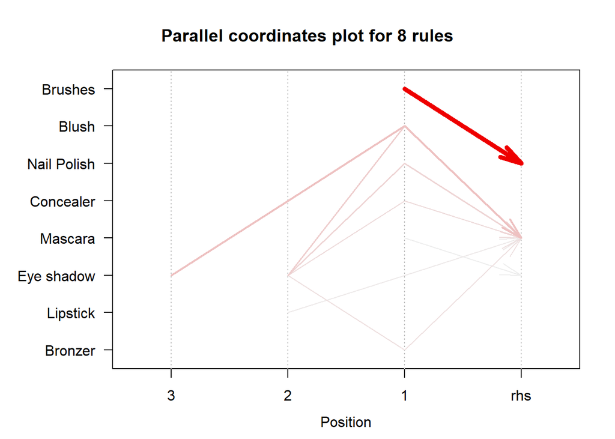

```r
plot(rules.pruned, method="paracoord",measure="lift", control=list(reorder=TRUE))
```

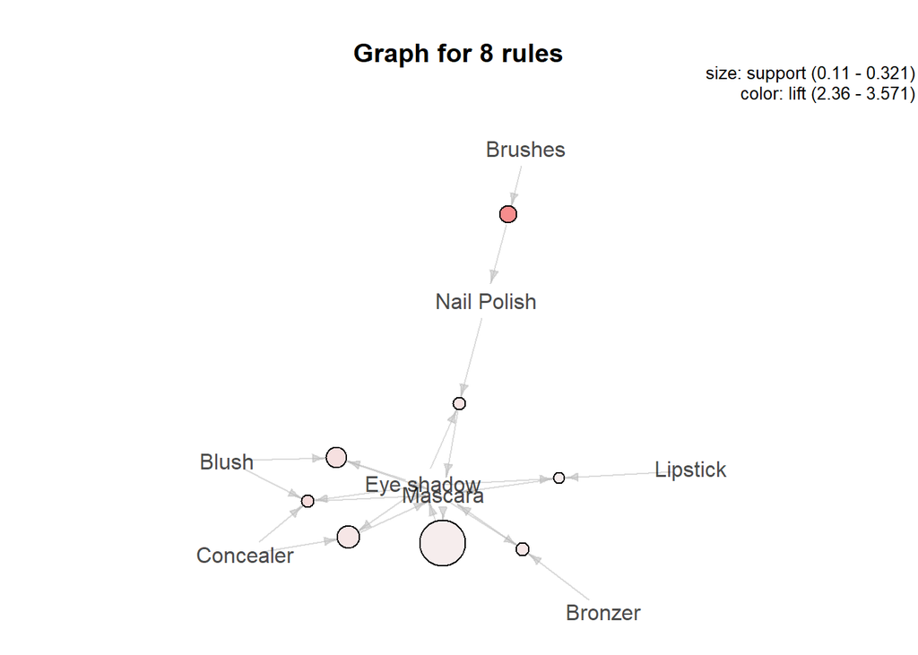

```r
plot(rules.pruned, method="graph")
```

## Inferences and interpretation

Rule mining could also be used to build recommendation systems such as the very popular netflix recommendation system (rules can be formed from cast and directors along with genre). cosine similarity is another algorithm used to build recommendation system.